# Erie: Unconstrained Ordination Analysis

Unconstrained ordinations are often used in the analysis of ecological data in order to determine how similar or dissimilar two samples are from each other. This is calculated through a comparison of species compositions. We will use two methods for this analysis: Principal Coordinate Analysis (PCoA) and Non-metric Multidimensional Scaling (NMDS). Both methods calculate a distance matrix from a species abundance matrix, but using different algorithms.

## Setup and import the data

```r
rm(list = ls())
gc()
```

```
##          used (Mb) gc trigger (Mb) max used (Mb)
## Ncells 525420 28.1    1170768 62.6   660862 35.3
## Vcells 971176  7.5    8388608 64.0  1800226 13.8
```

```r
library(tidyverse)
library(vegan)
library(ape)

erie <- readRDS("clean_data/erie.rds")
erie_meta <- readRDS("clean_data/erie_meta.rds")
erie_tax <- readRDS("clean_data/erie_tax.rds")
```

## Filter out samples with small read numbers

```r
erie_meta <- erie_meta %>%
             filter(sequencingDepth >= 10000)

erie_samples <- erie_meta %>%
                pluck("SampleID")

erie <- erie %>%
        filter(SampleID %>% is.element(erie_samples))
```

## Compute relative abundances and filter the data

Pivot the data and group by SampleID

```r
erie <- erie %>%
        pivot_longer(cols = starts_with("Otu"),
                     names_to = "OTU",
                     values_to = "Abundance") %>%
        group_by(SampleID)
```

Calculate the relative abundances and filter out all rows with a relative abundance less than or equal to 0.005%

```r
erie <- erie %>%
        mutate(Rel_Abundance = Abundance / sum(Abundance)) %>%
        filter(Rel_Abundance > 5e-5)
```

Ensure that we drop any OTUs in the taxonomy table which are no longer present in the erie table

```r
erie_tax <- erie_tax %>%
            semi_join(erie, by = "OTU")
```

Repivot the data back to original wide format

```r
erie <- erie %>%
        ungroup() %>%
        select(-c(Abundance)) %>%
        pivot_wider(names_from = "OTU",
                    values_from = "Rel_Abundance",
                    values_fill = 0)
```

## Generating the community matrix

```r
erie_rownames <- erie %>%
                 pluck("SampleID")
erie_matrix <- erie %>%
               select(starts_with("OTU")) %>%
               as.matrix() %>%
               `rownames<-`(erie_rownames)
```

## The PCoA Calculation

Calculate distances with the bray method

```r
erie_dist <- erie_matrix %>%
             vegdist(method = "bray")
```

Save the calculate to an RDS file for future use

```r
erie_dist %>% saveRDS("clean_data/erie_dist_matrix_bray.rds")
```

Perform the PCoA

```r
erie_pcoa <- erie_dist %>% pcoa()
```

Convert from matrix to tibble

```r
erie_pcoa_tib <- erie_pcoa %>%
                 pluck("vectors") %>%
                 .[,1:2] %>%
                 as_tibble(rownames = "SampleID") %>%
                 rename(pcoa.1 = Axis.1,
                        pcoa.2 = Axis.2)
```

Join the PCoA tibble to the meta data

```r
erie_meta <- erie_meta %>%
             left_join(erie_pcoa_tib)
```

## The NMDS Calculation

Seed the number generator for consistency and reuse the matrix from earlier for the calculation

```r
set.seed(02052001)
erie_nmds <- erie_dist %>%
             metaMDS(trymax = 200, sfgrmin = 1e-9, sratmax = 0.999999999)
```

```
## *** Solution reached
```

Convert from matrix to tibble

```r
erie_nmds_tib <- erie_nmds %>%
                 pluck("points") %>%
                 as_tibble(rownames = "SampleID") %>%
                 rename(nmds.1 = MDS1,
                        nmds.2 = MDS2)
```

Join the NMDS tibble to the meta data

```r
erie_meta <- erie_meta %>%
             left_join(erie_nmds_tib)
```

## Save the uncontrained ordination meta file

```r
erie_meta %>% saveRDS("clean_data/erie_meta_ordination.rds")
```

## Plot the PCoA and NMDS unconstrained ordinations

Ensure months are ordered correctly for the plot using factors

```r
erie_meta <- erie_meta %>%
             mutate(Month = factor(Month,
                                   levels = c("June", "July", "August", "September", "October")))
```

Create the PCoA plot

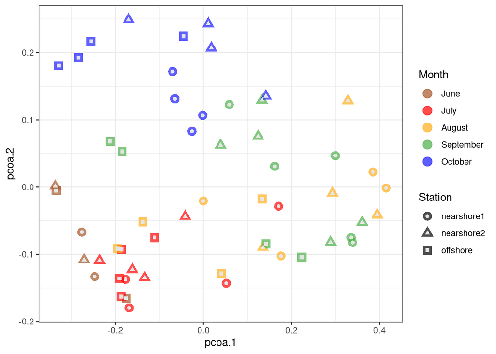

```r
ggplot(data = erie_meta,
       mapping = aes(x = pcoa.1,
                     y = pcoa.2,
                     color = Month,
                     shape = Station)) +
scale_color_manual(values = c("#a65628", "red", "#ffae19", "#4daf4a",
                              "#1919ff", "darkorchid3", "magenta")) +
geom_point(aes(color = Month),
           alpha = 0.7,
           size = 4) +
geom_point(colour = "grey90",
           size = 1.5) +
theme_bw()
```

Save plot to pdf

```r
ggsave("outputs/Erie_Unconstrained_Ordination_PCoA.pdf")
```

Create the NMDS plot

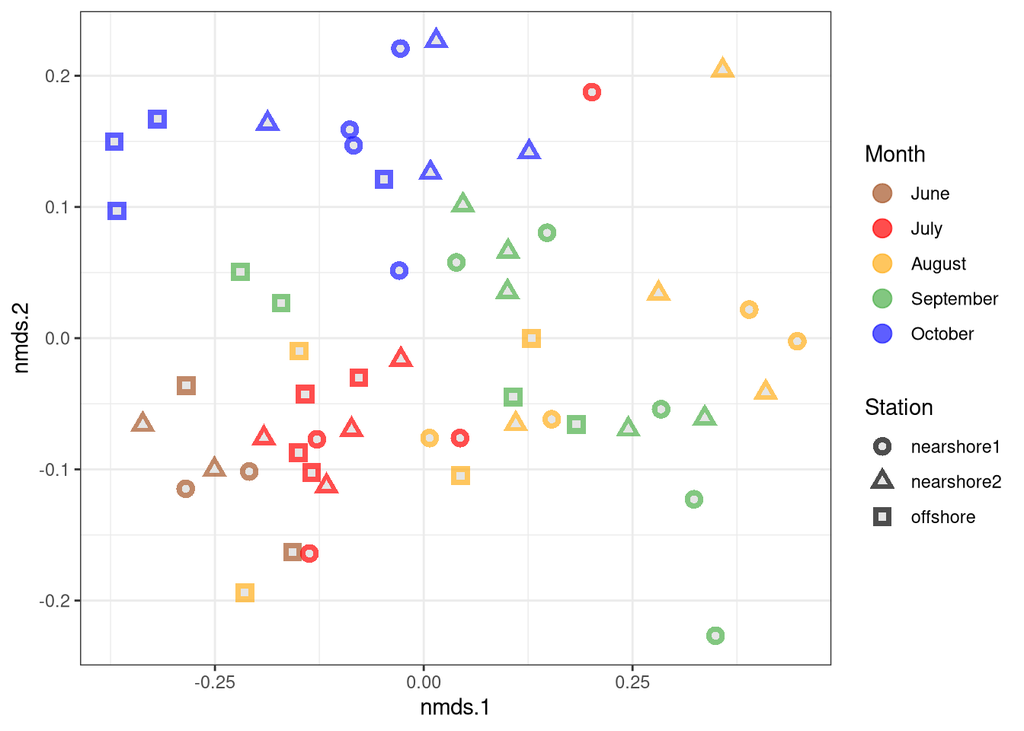

```r
ggplot(data = erie_meta,
       mapping = aes(x = nmds.1,
                     y = nmds.2,
                     color = Month,
                     shape = Station)) +
scale_color_manual(values = c("#a65628", "red", "#ffae19", "#4daf4a",
                              "#1919ff", "darkorchid3", "magenta")) +
geom_point(aes(color = Month),
           alpha = 0.7,
           size = 4) +
geom_point(colour = "grey90",
           size = 1.5) +
theme_bw()
```

Save plot to pdf

```r
ggsave("outputs/Erie_Unconstrained_Ordination_NMDS.pdf")
```

## Brief Analysis of the PCoA and NMDS plots

### PCoA

The PCoA plot shows a low species variation across stations for the June and July months, while the other months are more spread out and diverse. September and August appear to overlap the most in species abundances, while October’s abundances are the most separate from the other months. Which station as sample was taken at seems to have a much smaller affect on species similarity than the month. For October, the stations show the most separation from each other.

### NMDS

The NMDS plot shows a similar picture to the PCoA, though the June and July samples are more densely concentrated with the exception of one July outlier. Why the July nearshore1 sample is so far removed from the other July samples is worth investigating. Again, August and September show the most species similarities, while October has the least overlap with other months.

### Findings

The plots suggest there is little change in species composition in the June and July months, but throughout August and September we see a greater variation in species abundances and similarities. October shows the least species similarity with the other months, likely due to changing seasons and colder weather affecting the composition of bacteria in the water.